# Indo-European Pronouns

This file contains all the source code to generate the figures and statistical measures reported in the paper **Evolution and Spread of Politeness Systems in Indo-European**

Required data files

- `ie-v1.nex` (a sample of bayesian phylogenetic trees for the I-E language family; Dunn and Tresoldi 2021)
- `ie-v1.mcc.tre` (a Maximum Clade Consistency tree summarising the tree sample, for reference only)
- `language.metadata.csv` (ISO codes, geographic coordinates, and ancient/modern status)
- `SAE-features.csv` (presence/absence of SAE areal features, coded from Haspelmath list)
- `../data/pronoun-paradigms.csv` (an etic grid showing the pronominal forms used for each pronominal function attested in the family)

Generated files:

- `pronoun-similarity.csv` (a pairwise similarity table, generated from `pronoun-paradigms.csv` using the python script `../data/make-pronoun-similarity-table.py`; for each language each pair of pronominal functions are rated 1/same pronoun or 0/different pronouns)
- `pronoun-number-conflation.csv` (generated from `pronoun-paradigms.csv` with the script `../data/make_pronoun_conflation_table.py`; does the language ever conflate singular and plural for 2nd or 3rd person)
- `pronoun-distinct-politeness.csv` (generated from `pronoun-paradigms.csv` with the script `../data/make_pronoun_distinct_politeness_table.py`; does the language have distinct politeness forms in the 2sg and the 2pl?)
- `trees.rData` (saved intermediate results of this analysis)
- `simmap.rData` (saved intermediate results of this analysis)
- `results.rData` (saved results of this analysis)

To regenerate the analysis cleanly you need to delete the three `.rData` files, otherwise saved values will be used. The `tree.sample.size` variable is set at 400, which is an acceptable value for the full test, but this is slow and it can be set to a lower value for testing.

```r
#library(logisticPCA)
library(ape)
library(vegan)
library(parallel)
library(phytools)
library(rnaturalearth)
library(tidyverse)
```

```r
library(ggrepel)
library(gridExtra) # for grid.arrange
options(ggrepel.max.overlaps = Inf)

MC.CORES <- detectCores() # Use all available processing power
cat(paste("--> Using", MC.CORES, "cores\n"))
```

```
## --> Using 12 cores
```

As a sanity check, transform the pronoun paradigm similarities into an inter-language distance measure. A cluster plot of the distance matrix showing structurally similar languages clustered together. Note that this is *not* a phylogeny!

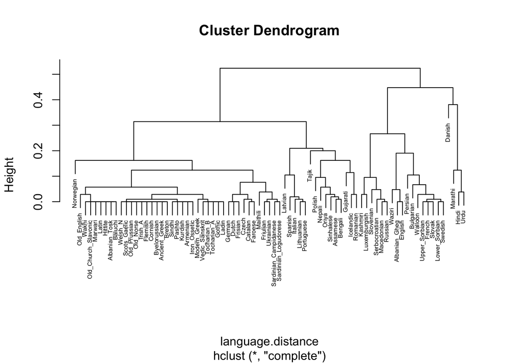

```r
# The similarity features are comparisions of every pair of cells in a pronoun paradigm,
# calculated per language
pairwise.similarity <- read.delim("pronoun-similarity.csv", row.names=1, header=TRUE)
language.distance <- dist(pairwise.similarity,  method="manhattan") / ncol(pairwise.similarity)
plot(hclust(language.distance), cex=0.5)
```

Prepare metadata

```r
metadata <- read_tsv("language-metadata.csv")
sae.features <- read.delim("SAE-features.csv", row.names=1)
sae.sum <- apply(sae.features, 1, sum)[metadata$language]
metadata$sae.score <- sae.sum
metadata$SAE <- sae.sum > 4
metadata
```

| language | iso.code | latitude | longitude | ancient | sae.score | SAE |
| --- | --- | --- | --- | --- | --- | --- |
| Icelandic | isl | 63.484 | -19.021 | FALSE | 6 | TRUE |
| Irish_A | gle | 53.398 | -9.347 | FALSE | 1 | FALSE |
| Portuguese | por | 39.441 | -7.839 | FALSE | 8 | TRUE |
| Faroese | fao | 62.073 | -6.885 | FALSE | 6 | TRUE |
| Scots_Gaelic | gla | 56.757 | -5.244 | FALSE | 1 | FALSE |
| Welsh_N | cym | 51.975 | -4.221 | FALSE | 0 | FALSE |
| Cornish | cor | 50.523 | -4.186 | FALSE | 1 | FALSE |
| Breton | bre | 48.245 | -3.789 | FALSE | 2 | FALSE |
| Spanish | spa | 40.029 | -2.988 | FALSE | 8 | TRUE |
| English | eng | 53.277 | -2.238 | FALSE | 7 | TRUE |

[output cut: 67 more lines]

```r
#View(metadata)
```

Summarise data with PCA

```r
# temporary fix for missing values
sae.features[is.na(sae.features)] <- 0

pca_model <- prcomp(language.distance, scale=TRUE)$x %>%
  as.data.frame() %>%
  mutate(language=rownames(.)) %>%
  left_join(metadata) %>%
  filter(!is.na(iso.code)) # rm non-IE languages
```

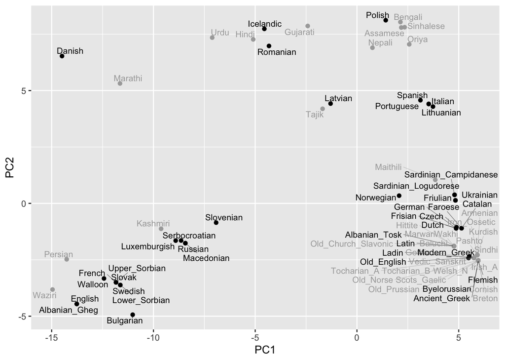

```r
pca_model %>%
 ggplot(aes(x=PC1, y=PC2, label=language, colour=SAE)) +
  geom_point() +
  scale_colour_manual(values=c("darkgray", "black")) +
  geom_text_repel(size=3, segment.size=0.25, segment.alpha=0.5, box.padding=0.1) +
  theme(legend.position = "none")
```

```r
ggsave("../figures/Figure_2_PCA.png", width=5.75, height=5.75, units="in")
ggsave("../figures/Figure_2_PCA.pdf", width=5.75, height=5.75, units="in")
```

Supplementary figure 1 shows that PC1 can be characterised as distinguishing languages which have person-number conflation, operationalised as the answer to the question *does the language ever conflate singular and plural for 2nd or 3rd person?*; this is calculated from the pronoun paradigm data in `pronoun-paradigms.csv` using the script `make_pronoun_conflation_table.py`. Languages with person-number conflation tend to be loaded negatively on PC1.

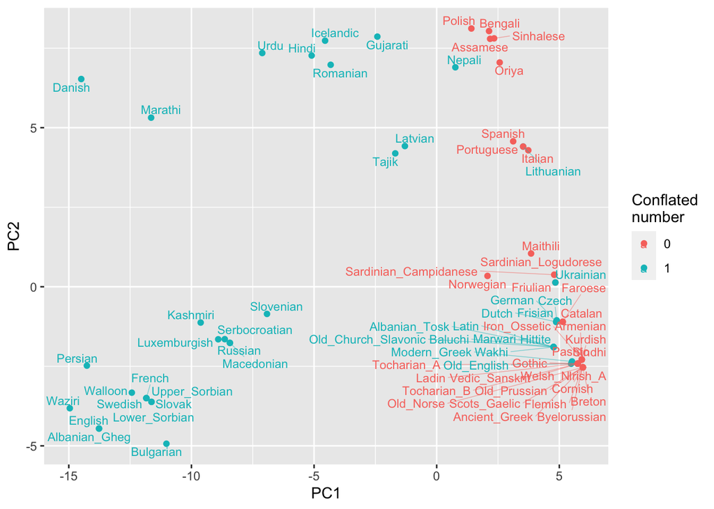

```r
pca_model %>%
  left_join(read_tsv("pronoun-number-conflation.csv")) %>%
  ggplot(aes(x=PC1, y=PC2, label=language, colour=as.factor(conflation))) +
  geom_point() +
  geom_text_repel(size=3, segment.size=0.25, segment.alpha=0.5, box.padding=0.1) +
  labs(colour="Conflated\nnumber")
```

```r
ggsave("../figures/Supplementary_Figure_1.pdf", width=5.75, height=5.75, units="in")
```

Supplementary figure 2 shows that PC2 distinguishes languages which have distinct politeness forms in the singular and plural (languages with distinct politeness forms in the singular and plural are weighted positively); note that while this is a distinctive feature of IE pronominal paradigms, it does not seem to be diagnostic of the SAE linguistic area.

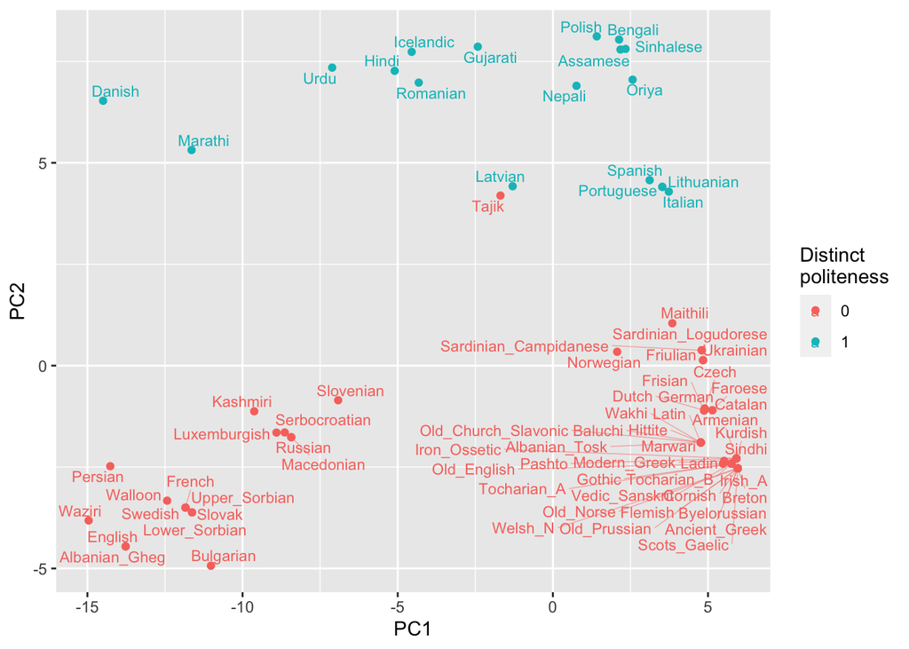

```r
pca_model %>%
  left_join(read_tsv("pronoun-distinct-politeness.csv")) %>%
  ggplot(aes(x=PC1, y=PC2, label=language, colour=as.factor(distinct))) +
  geom_point() + #geom_point(aes(shape=SAE)) +
  geom_text_repel(size=3, segment.size=0.25, segment.alpha=0.5, box.padding=0.1) +
  labs(colour="Distinct\npoliteness")
```

```r
ggsave("../figures/Supplementary_Figure_2.pdf", width=5.75, height=5.75, units="in")
```

## Data transformation

Prepare the tree sample if the file `trees.rData` doesn’t already exist (this is a slow process, so we don’t want to repeat it if not necessary). To force regeneration of `trees.rData` delete the current version of the file along with other `.rData` files.

Sanity check: Load a reference tree, fix the tree labels, and plot it

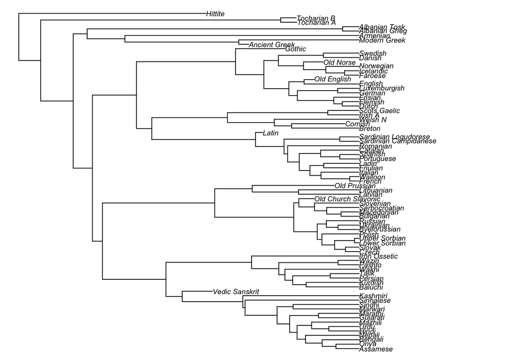

```r
all.languages <- metadata %>% pull(language)
namehash <- c( # convert tree names to names used in analysis or to proxy languages
  # proxies are languages which are in the equivalent position in the tree
  "Arvanitika"="Albanian_Gheg",
  "Tosk"="Albanian_Tosk",
  "Eastern_Armenian"="Armenian",
  "Belarusian"="Byelorussian",
  "Irish"="Irish_A",
  "Digor_Ossetic"="Iron_Ossetic",
  "Luxembourgish"="Luxemburgish",
  "Bihari"="Maithili",
  "Old_Church_Slavic"="Old_Church_Slavonic",
  "Old_West_Norse"="Old_Norse",
  "Cagliari"="Sardinian_Campidanese",
  "Nuorese"="Sardinian_Logudorese",
  "Serbian"="Serbocroatian",
  "Singhalese"="Sinhalese",
  "Welsh"="Welsh_N")

mcc.tre <- read.nexus("ie-v1.mcc.tre")
mcc.tre$tip.label <- recode(mcc.tre$tip.label, !!!namehash)
mcc.tre <- ladderize(root(keep.tip(mcc.tre, all.languages), "Hittite"))
plot(mcc.tre, no.margin=TRUE, cex=0.6)
```

```r
states.pca <- data.frame(
  PC1=round(pca_model$PC1,5),
  PC2=round(pca_model$PC2,5)) #,
  #feat.sum=pca_model$sae.score)
row.names(states.pca) <- pca_model$language

tree.sample.size <- 400 # set this to e.g. 20 for testing, 400+ for a full analysis

if (!file.exists("trees.rData")){
  TREEFILE <- "ie-v1.nex" # this sample is 10000 trees, which is much too long

  trees <- read.nexus(TREEFILE)
  # drop the first half of the trees as burnin, and filter the remaining sample to a reasonable size
  trees <- trees[seq(length(trees)/2, length(trees), length.out=tree.sample.size)]

  tree.list <- mclapply(trees,
    function(tree) {
      # fix labels
      tree$tip.label <- recode(tree$tip.label, !!!namehash)
      # scale edge lengths (there are sometimes errors when numbers are too large)
      tree$edge.length <- tree$edge.length / 1000
      # root on Hittite
      ladderize(root(keep.tip(tree, all.languages), "Hittite"))
      },
    mc.cores=MC.CORES)

  class(tree.list) <- "multiPhylo"

  save(tree.list, states.pca, mcc.tre, file="trees.rData")
}
```

## Simulate SAE history

Plot these states on a map.

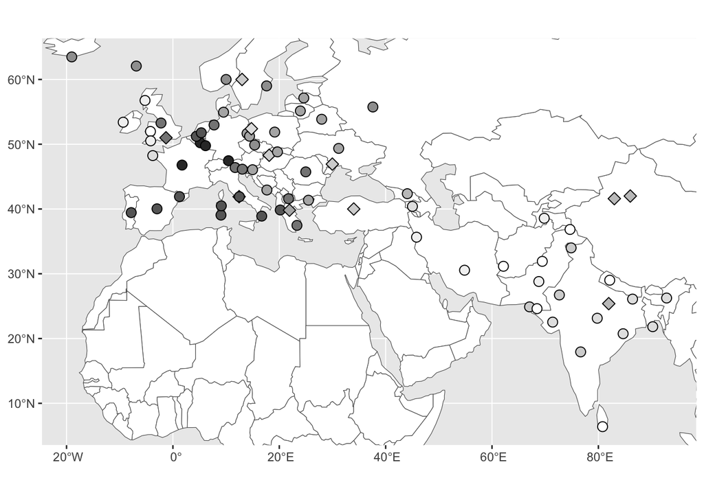

```r
world = ne_countries(scale = "small", returnclass = "sf")

ggplot(data=world) +
  geom_sf(fill="white") +
  coord_sf(xlim = range(metadata$longitude), ylim = range(metadata$latitude)) +
  geom_point(data=metadata, aes(x = longitude, y = latitude, shape=ancient, fill=as.factor(sae.score)), size=3, colour="black") +
  scale_shape_manual(values=c(21,23))+
  scale_fill_grey(start=1, end=0.2) +
  theme(legend.position = "none", axis.title.x=element_blank(), axis.title.y=element_blank())
```

```r
ggsave("../figures/Figure_1_Map.pdf", width=5.75, height=3.75, units="in")
ggsave("../figures/Figure_1_Map.png", width=5.75, height=3.75, units="in")
```

Plot the distribution of SAE feature counts

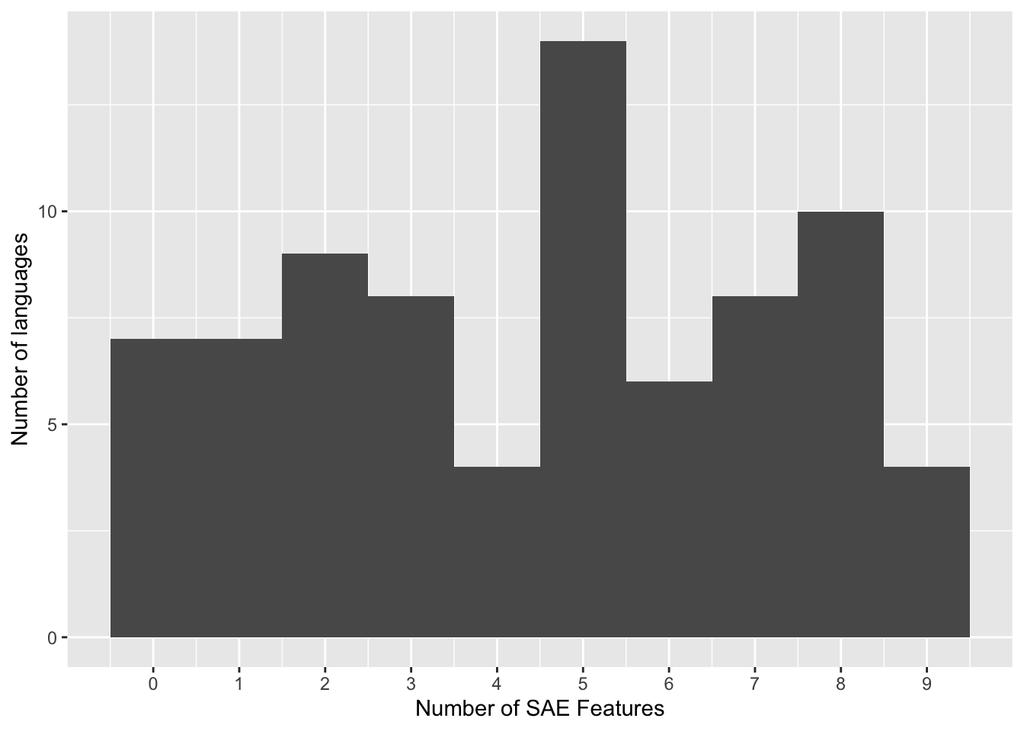

```r
metadata %>%
  ggplot(aes(x=sae.score)) +
  geom_histogram(binwidth=1) +
  scale_x_continuous(breaks=0:9) +
  xlab("Number of SAE Features") + ylab("Number of languages")
```

```r
ggsave("../figures/Figure_3_SAE.png", width=3, height=2)
ggsave("../figures/Figure_3_SAE.pdf", width=3, height=2)
```

## Demonstrate a simmap

```r
observed.states <- metadata %>% pull(SAE) %>% as.integer()
names(observed.states) <- metadata %>% pull(language)
# make.simmap rate models: "ARD" all rates different; "SYM" symmetrical; "EQ"" equal; or use matrix
dollo.model = matrix(c(0,0,1,0), 2) # once a lineage becomes SAE it doesn't revert to non-SAE
simmap.tre <- make.simmap(mcc.tre,
  observed.states,
  model=dollo.model)
```

```
## make.simmap is sampling character histories conditioned on
## the transition matrix
##
## Q =
##            0         1
## 0 -0.0001069 0.0001069
## 1  0.0000000 0.0000000
## (estimated using likelihood);
## and (mean) root node prior probabilities
## pi =
##   0   1
## 0.5 0.5
```

```
## Done.
```

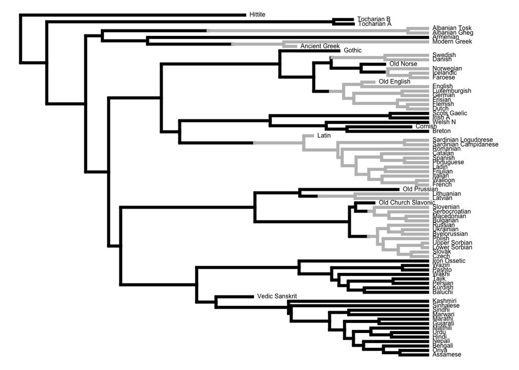

```r
cols <- c("black", "gray")
names(cols) <- c("0", "1")
plotSimmap(simmap.tre, cols, fsize=0.5, pts=FALSE, lwd=4)
```

Plot three arbitrary simmaps to show variation in tree structure (from the Bayesian phylogenetic sampling process) and simulated history

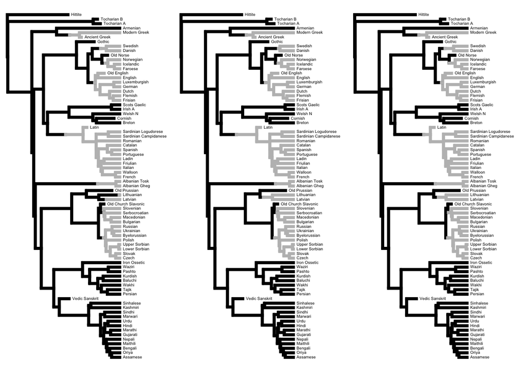

```r
opar <- par(no.readonly=TRUE)
par(mfrow=c(1,3))
plot.simmap.i <- function(i){
  cols <- c("black", "gray")
  names(cols) <- c("0", "1")
  plot(simmap.list[[i]], cols, fsize=0.5, pts=FALSE, lwd=4)}

plot.simmap.i(1)
plot.simmap.i(2)
plot.simmap.i(3)
```

```r
par(opar)
```

```r
pdf("../figures/Figure_4_State_Simulation.pdf", width=7, height=4.5)
par(mfrow=c(1,3))
plot.simmap.i(1)
plot.simmap.i(2)
plot.simmap.i(3)
dev.off()
```

Now do the `brownie.lite` test (O’Meara et al. 2006).

```r
NTREES <- length(simmap.list)
results.trait.m <- matrix( # template results matrix
  nrow=NTREES,
  ncol=12,
  dimnames=list(1:NTREES,
    c("BM.singlerate","logL.singlerate", "k1", "1rate.AICc", "NonSAE.rate",
      "SAE.rate","logL.multiplerate", "k2", "2rate.AICc", "pchisq",
     "converged", "delta.AICc"))
  )

if (!file.exists("results.rData")){
  process.results <- function(trait.name){
    results.trait.name <- results.trait.m
    traits <- states.pca[[trait.name]]
    names(traits) <- row.names(states.pca)
    for (i in 1:NTREES){
      cat(paste("Trait ", trait.name, " trial ", i, "/", NTREES, "\n", sep=""))
      # check that labels are aligned
      stopifnot(all(sort(simmap.list[[i]]$tip.label) == sort(names(traits))))
      fit <- NA
      tryCatch(
        fit <- brownie.lite(simmap.list[[i]], traits, test="chisq"),
          error=function(e) {}
        )
        if (length(fit) != 1){
          # calculate AICc for 1 and 2 rate models
          fit1aicc<-(-2*fit$logL1+2*fit$k1+((2*fit$k1*(fit$k1+1))/(90-fit$k1-1)))
          fit2aicc<-(-2*fit$logL.multiple+2*fit$k2+((2*fit$k2*(fit$k2+1))/(90-fit$k2-1)))

          results.trait.name[i,]<- as.numeric(c(
              fit$sig2.single,
              fit$logL1,
              fit$k1,
              fit1aicc,
              fit$sig2.multiple[sort(names(fit$sig2.multiple))][[1]],
              fit$sig2.multiple[sort(names(fit$sig2.multiple))][[2]],
              fit$logL.multiple,
              fit$k2,
              fit2aicc,
              fit$P.chisq,
              fit$convergence == "Optimization has converged.",
              fit1aicc-fit2aicc
              ))
        }
    }
    results.trait.name
  }
  results <- mclapply(names(states.pca), process.results,
    mc.cores=min(MC.CORES, length(names(states.pca))))
  names(results) <- names(states.pca)
  save(results, file="results.rData")
} else load("results.rData")
```

Get rate estimates (report in article text)

```r
trait_labels <- c("PC1", "PC2")
# trait_labels <- c("PC1", "PC2", "feat.sum")
lapply(trait_labels, function(d) as_tibble(results[[d]])) %>%
  set_names(trait_labels) %>%
  bind_rows(.id="trait") %>%
  pivot_longer(c("logL.singlerate", "logL.multiplerate"), names_to="model", values_to="rate") %>%
  group_by(trait, model) %>%
  summarise(median_rate=median(rate))
```

| trait | model | median_rate |
| --- | --- | --- |
| PC1 | logL.multiplerate | -275.5 |
| PC1 | logL.singlerate | -278.7 |
| PC2 | logL.multiplerate | -206.9 |
| PC2 | logL.singlerate | -212.7 |

## delta AICc

Compare AIC for one rate and two rate models

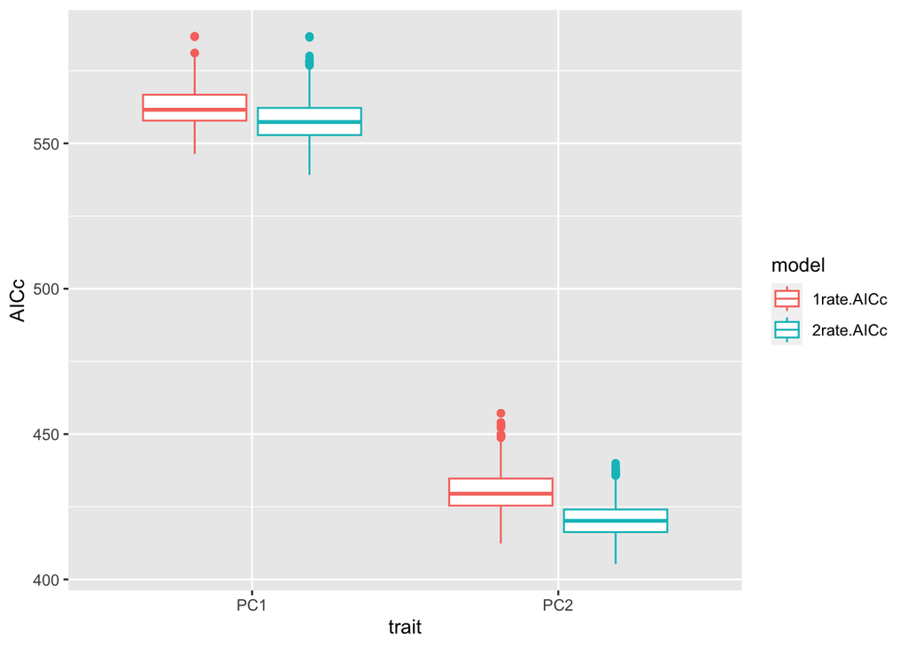

```r
trait_labels <- c("PC1", "PC2")
# trait_labels <- c("PC1", "PC2", "feat.sum")


lapply(trait_labels, function(d) as_tibble(results[[d]])) %>%
  set_names(trait_labels) %>%
  bind_rows(.id="trait") %>%
  pivot_longer(c("1rate.AICc", "2rate.AICc"), names_to="model", values_to="AICc") %>%
  ggplot(aes(x=trait, y=AICc, colour=model)) + geom_boxplot()
```

Change in AIC gives a measure of how much one model should be preferred over the other

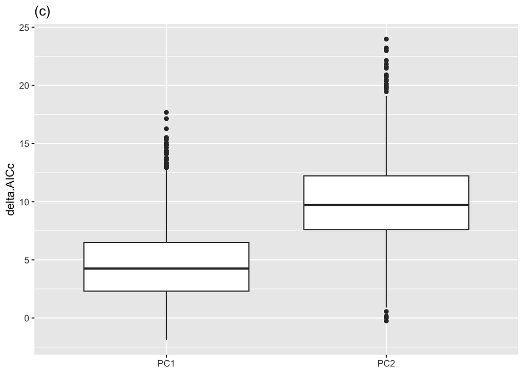

```r
fig5c <- lapply(trait_labels, function(d) as_tibble(results[[d]])) %>%
  set_names(trait_labels) %>%
  bind_rows(.id="trait") %>%
  ggplot(aes(x=trait, y=delta.AICc)) +
  geom_boxplot() +
  labs(title="(c)") +
  theme(axis.title.x=element_blank())
fig5c
```

Report median change in AICc in text

```r
lapply(trait_labels, function(d) as_tibble(results[[d]])) %>%
  set_names(trait_labels) %>%
  bind_rows(.id="trait") %>%
  group_by(trait) %>%
  summarise(median.delta.AIC.c=median(delta.AICc), evidence.ratio=exp(0.5*median(delta.AICc)))
```

| trait | median.delta.AIC.c | evidence.ratio |
| --- | --- | --- |
| PC1 | 4.256 | 8.4 |
| PC2 | 9.711 | 128.5 |

For the two rate model, how the estimated rates of evolution of each component in the SAE and non-SAE regions of the trees.

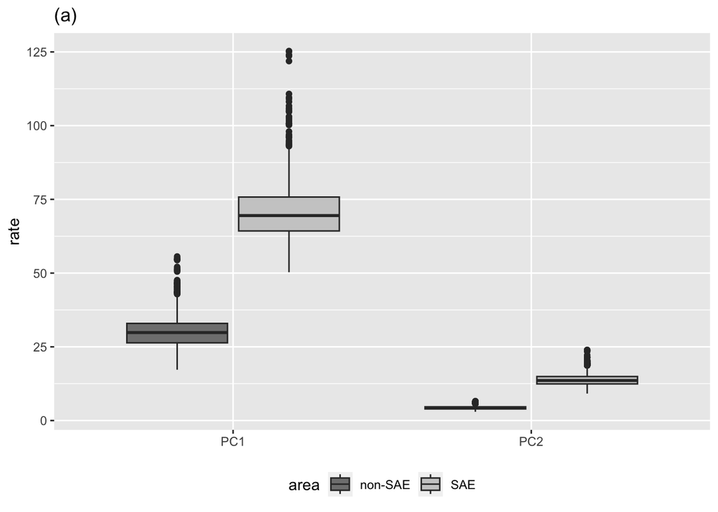

```r
fig5a <- lapply(trait_labels, function(d) as_tibble(results[[d]])) %>%
  set_names(trait_labels) %>%
  bind_rows(.id="trait" ) %>%
  pivot_longer(c("SAE.rate", "NonSAE.rate"), names_to="area", values_to="rate") %>%
  mutate(area=if_else(area=="SAE.rate", "SAE", "non-SAE")) %>%
  ggplot(aes(x=trait, y=rate, fill=area)) +
  geom_boxplot() +
  theme(legend.position = "bottom") +
  scale_fill_grey(start=0.5, end=0.8)+
  labs(title="(a)") +
  theme(axis.title.x=element_blank())
fig5a
```

Summarise the relative rate of evolution of each component for SAE versus non-SAE parts of the tree

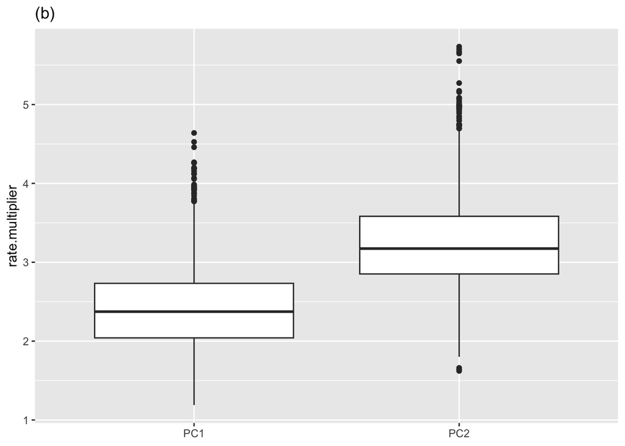

```r
fig5b <- lapply(trait_labels, function(d) as_tibble(results[[d]])) %>%
  set_names(trait_labels) %>%
  bind_rows(.id="trait" ) %>%
  mutate(rate.multiplier=SAE.rate/NonSAE.rate) %>%
  ggplot(aes(x=trait, y=rate.multiplier)) + geom_boxplot() +
  labs(title="(b)") +
  theme(axis.title.x=element_blank())
fig5b
```

```r
lapply(trait_labels, function(d) as_tibble(results[[d]])) %>%
  set_names(trait_labels) %>%
  bind_rows(.id="trait" ) %>%
  mutate(rate.multiplier=SAE.rate/NonSAE.rate) %>%
  group_by(trait) %>%
  summarise(median.rate.multiplier=median(rate.multiplier))
```

| trait | median.rate.multiplier |
| --- | --- |
| PC1 | 2.374 |
| PC2 | 3.174 |

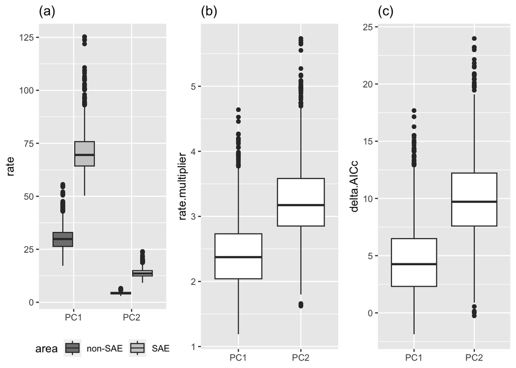

```r
fig5 <- grid.arrange(fig5a, fig5b, fig5c, nrow=1)
```

```r
ggsave("../figures/Figure_5_results.png", plot=fig5, width=7, height=3)
ggsave("../figures/Figure_5_results.pdf", plot=fig5, width=7, height=3)
```

## References

Dunn, Michael and Tresoldi, Tiago. 2021. Indo-European Lexical Data (IELex) and ‘Good Enough’ Tree. Uppsala: Uppsala universitet. Available at: https://github.com/evotext/ielex-data-and-tree ; DOI: 10.5281/zenodo.5556801

Haspelmath, Martin. 2001. “The European Linguistic Area: Standard Average European.” Language Typology and Language Universals: An International Handbook 2: 1492–1510.

O’Meara, Brian .C., Cécile Ané, Michael J. Sanderson, and Peter C. Wainwright. 2006. Testing for different rates of continuous trait evolution using likelihood. *Evolution* 60(5): 922-933.